# 沙市堂 主日崇拜 · Shashi Church Sunday Worship

**2026年9月27日（主日）· Sunday 27 September 2026 · 上午 9:00**  
主礼 Presiding: **彭金文 牧师** (pastor) · 证道 Sermon: **丁志云 传道** (evangelist)  
晚堂 Evening service 19:00 at **香榭丽都聚会点** (江津中路, opposite RT-Mart 大润发): 主礼 段光霞 传道 · 证道 丁志云 传道  
温馨提示 After the service: 灵命栽培课程 (a discipleship / spiritual-nurture class) in the 2nd-floor classroom.

This Sunday sits between 中秋节 (Mid-Autumn Festival, 25 Sept — the family-reunion festival) and 国庆节 (National Day, 1 Oct): that is why the choir sings《求主福佑中华歌》*Lord, Bless China*, and why the hymns turn to marriage, elders and family.

# 今日主题 · Today’s Theme

**基督徒的新生活 — the Christian’s new life, at home and at work.** Last week’s text (Col 3:12–17) described the clothes of the new self: compassion, forgiveness, love, peace, the word of Christ, thanksgiving. This week Paul continues without a break (3:18–4:1) and shows what those clothes look like in the three relationships of an ancient household — 夫妻 husband and wife, 亲子 parent and child, 主仆 master and servant. Two things make his version different from the household rules of his day. First, he speaks *to* wives, children and slaves directly, as responsible people (Greek and Roman writers only addressed the head of the house). Second, every duty is qualified **在主里 “in the Lord”**, and the powerful party gets the harder command: husbands *love and don’t be harsh*, fathers *don’t provoke or discourage*, masters *be just and fair — you too have a Master in heaven*. The hinge sentence is 3:23: **无论做什么，都要从心里做，像是给主做的，不是给人做的** — whatever you do, do it from the heart, as for the Lord and not for people.

The three lessons widen the frame from the household to God’s own way of dealing with people: **约拿 Jonah** sulking under his withered plant while God pities Nineveh; **保罗 Paul** in prison saying “to live is Christ”; and the **葡萄园工人 workers in the vineyard**, where the latecomers are paid a full day. All three say that God’s generosity is not wages — which is exactly the spirit a Christian master (or parent, or spouse) is asked to show. The psalm (145) adds the elders’ theme: 这代要对那代颂赞你的作为 — one generation tells the next what God has done.

*Lectionary note: Jonah 3:10–4:11, Ps 145, Phil 1:21–30 and Matt 20:1–16 are the Revised Common Lectionary set for Year A, Proper 20 (the church runs one week behind the RCL calendar); Colossians 3:18–4:1 is its own sermon series, continuing from last Sunday.*

原程序单截图 original bulletin →

1. **序乐 Prelude** — 诗班、主礼人、证道人等入堂 choir, presider and preacher enter · 众立·安静 stand, silent
2. **问安 Greeting** — 赞美诗 396《主在圣殿中》Hymn 396 *The Lord Is in His Holy Temple* · 众立·同唱
3. **宣召 Call to Worship** — 诗篇 Psalm 145:1, 4–7 · 众立
4. **唱诗 Hymn** — 赞美诗 187《完全恩爱歌》Hymn 187 *O Perfect Love* · 众立·同唱
5. **祷告 Prayer** (opening prayer) · 众立·安静
6. **宣信 Confession of Faith** — 赞美诗 395《使徒信经》Apostles’ Creed · 众立·同诵
7. **诗班献唱 Choir Anthem** — 赞美诗 177《求主福佑中华歌》Hymn 177 *Lord, Bless China* · 众坐
8. **经训 Scripture Lessons** — 拿 Jonah 3:10–4:11 · 腓 Phil 1:21–30 · 太 Matt 20:1–16 · 会众同应 responsive
9. **读经 Sermon Text** — 西 Col 3:18–4:1 · 众坐
10. **唱诗 Hymn** — 赞美诗 189《敬老尊长歌》Hymn 189 *Honour the Aged* · 众立·同唱
11. **证道 Sermon** —《基督徒的新生活》*The Christian’s New Life* · 众坐·安静
12. **堂务报告 Announcements** · 众坐
13. **欢迎第一次来的朋友 Welcome to First-Time Visitors** · 众坐
14. **祷告 Prayer** — 为有需要者祷告 for those in need · 众坐·安静
15. **唱诗 Hymn** — 赞美诗 312《学象耶稣歌》Hymn 312 *Lord, I Want to Be a Christian* · 众立·同唱
16. **主祷文 The Lord’s Prayer** — 马太福音 Matt 6:9–13 · 众立·同诵
17. **祝福 Benediction** · 众立
18. **阿们颂 Amen** · 众立·同唱

# 逐项解读 · Walk-Through ↑

## 1 · 序乐 Prelude — 众立·安静 ↑

**主题 Theme:** Silence first — the service begins by listening. Hymns are from《赞美诗（新编）》(the 1983 *Chinese New Hymnal*, 400 hymns); numbers are announced as 赞美诗第…首.

Organ/piano prelude while the 诗班 (choir), 主礼人 (presider) and 证道人 (preacher) process in. Everyone stands and keeps silent.

## 2 · 问安 Greeting — 赞美诗 396《主在圣殿中》· 众立·同唱 ↑

**主题 Theme:** “The Lord is in his holy temple” — the same stillness the whole service asks for before God speaks.

♪ 五线谱 score →

Sung softly as an introit (哈巴谷书 Habakkuk 2:20); music by George F. Root (1820–1895). After it the presider greets: **弟兄姊妹，主内平安！** — the congregation answers **平安！**

主在圣殿中，主在圣殿中，普天下的人，在主面前都应当肃静，肃静，肃静，应当肃静。阿们。  
The Lord is in His holy temple, the Lord is in His holy temple; let all the earth keep silence, let all the earth keep silence before Him; keep silence, keep silence before Him. Amen.

## 3 · 宣召 Call to Worship — 诗篇 Psalm 145:1, 4–7 · 众立 ↑

**主题 Theme:** One generation tells the next what God has done (v. 4) — the elders-and-children thread of the day, and the reason for hymn 189.

<sup>1</sup> 我的神我的王啊，我要尊崇你！我要永永远远称颂你的名！  
<sup>1</sup> I will exalt you, my God, the King. I will praise your name forever and ever.  
<sup>4</sup> 这代要对那代颂赞你的作为，也要传扬你的大能。  
<sup>4</sup> One generation will commend your works to another, and will declare your mighty acts.  
<sup>5</sup> 我要默念你威严的尊荣和你奇妙的作为。  
<sup>5</sup> Of the glorious majesty of your honor, of your wondrous works, I will meditate.  
<sup>6</sup> 人要传说你可畏之事的能力；我也要传扬你的大德。  
<sup>6</sup> Men will speak of the might of your awesome acts. I will declare your greatness.  
<sup>7</sup> 他们记念你的大恩就要传出来，并要歌唱你的公义。  
<sup>7</sup> They will utter the memory of your great goodness, and will sing of your righteousness.

**背景 Background.** Psalm 145 is the last psalm with David’s name on it and an alphabet psalm: each verse begins with the next Hebrew letter (the 和合本 heading 大卫的赞美诗 is the only psalm actually titled “praise”). Its centre, v. 8 (not read today), repeats God’s self-description from Exodus 34:6 — *gracious, merciful, slow to anger, abounding in steadfast love* — the very words 约拿 Jonah will throw back at God in the first lesson (拿 4:2). Verses 4–7 are about handing praise down: 这代要对那代 one generation to another; 传说 / 传扬 / 记念 tell, proclaim, remember.

## 4 · 唱诗 Hymn — 赞美诗 187《完全恩爱歌》· 众立·同唱 ↑

**主题 Theme:** The sermon’s first point is husbands and wives; the congregation first sings the church’s wedding prayer for “the love which knows no ending”.

♪ 五线谱 score →

**“O Perfect Love.”** Words by Dorothy Frances Gurney (1858–1932), written in 1883 for her sister’s wedding — by her own account in a quarter of an hour, to fit a tune the sister wanted. The tune the whole English-speaking world now uses, O PERFECT LOVE, was written by Joseph Barnby in 1889 for a royal wedding (Princess Louise of Wales). Chinese by 刘廷芳 1934 for 普天颂赞. Section: 教会生活·婚姻喜庆 (church life — weddings). E-flat major.

**1.** 完全的爱，超过人间的思想，虔诚信众，向主屈膝颂扬，为此佳偶，求主厚赐恩无量，主作之合，恩爱地久天长。  
**2.** 完全生命，恳求为他们保证，温柔的爱，永久不移的信，有恒的望，壮胆平心的坚忍，纯洁天真，艰难痛苦不惊。  
**3.** 求赐他俩，欢心消尽了愁心，求赐他俩，平安宁息纷争；百年偕老，又加灿烂的前程，重见黎明，恩爱生命永恒。阿们。

**1.** O perfect Love, all human thought transcending, lowly we kneel in prayer before Thy throne, that theirs may be the love which knows no ending, whom Thou forevermore dost join in one.  
**2.** O perfect Life, be Thou their full assurance of tender charity and steadfast faith, of patient hope and quiet, brave endurance, with childlike trust that fears nor pain nor death.  
**3.** Grant them the joy which brightens earthly sorrow; grant them the peace which calms all earthly strife, and to life’s day the glorious unknown morrow that dawns upon eternal love and life.

## 5 · 祷告 Prayer — 众立·安静 ↑

**主题 Theme:** The opening prayer usually includes confession — the new life begins with being forgiven, not with trying harder.

The presider’s opening prayer: praise, confession, and asking God’s presence on the service. Stand quietly; join in the closing **阿们**.

## 6 · 宣信 Confession of Faith — 赞美诗 395《使徒信经》· 众立·同诵 ↑

**主题 Theme:** 我信圣徒相通 — “the communion of saints”: the family of God that today’s household code is really about.

♪ 五线谱 score →

The Apostles’ Creed, recited together (hymnal 395 also prints John Stainer’s chant setting). 上帝 here and 神 in the Bible text are both “God” — the hymnal’s and the 和合本 神-edition’s conventions.

我信上帝，全能的父，创造天地的主。我信我主耶稣基督，上帝独生的子；因圣灵感孕，由童贞女马利亚所生；在本丢彼拉多手下受难，被钉于十字架，受死，埋葬；降在阴间，第三天从死人中复活；升天，坐在全能父上帝的右边；将来必从那里降临，审判活人死人。我信圣灵；我信圣而公之教会；我信圣徒相通；我信罪得赦免；我信身体复活；我信永生。阿们。

I believe in God, the Father almighty, creator of heaven and earth. I believe in Jesus Christ, his only Son, our Lord, who was conceived by the Holy Spirit, born of the Virgin Mary, suffered under Pontius Pilate, was crucified, died, and was buried; he descended to the dead. On the third day he rose again; he ascended into heaven, he is seated at the right hand of the Father, and he will come to judge the living and the dead. I believe in the Holy Spirit, the holy catholic Church, the communion of saints, the forgiveness of sins, the resurrection of the body, and the life everlasting. Amen.

## 7 · 诗班献唱 Choir Anthem — 赞美诗 177《求主福佑中华歌》· 众坐 ↑

**主题 Theme:** Prayer for the nation four days before 国庆节 National Day — the household widened to the country: 祖宗家园父母所在, “the home of our ancestors, where our parents are”.

♪ 五线谱 score →

**“Lord, Bless China” (求主福佑中华).** A Chinese original written for the New Hymnal: words 孙彦理 (Sun Yanli, 1981), music 史奇珏 (Shi Qijue, 1982). Section: 教会生活·为国求福 (church life — prayer for the nation). It is the hymnal’s patriotic hymn and is sung around National Day; stanza 3 names the 三自 “Three-Self” principle (self-governing, self-supporting, self-propagating) and the motto 爱国爱教 “love the country, love the church” of the registered church. B-flat major, 4/4, with a refrain.

**1.** 主恩浩大，福佑中华，悠久历史灿烂文化；前程似锦日丽中天，炎黄后裔蒙福无涯。  
**2.** 江山多娇，人民勤劳，神恩福泽如水滔滔；历代贡献造福人群，源远流长显主荣耀。  
**3.** 中华教会主所建造，主是根基永不动摇；三自精神合主心意，见证福音爱国爱教。  
**4.** 主的儿女神所选召，遵主圣训循主教导；同心协力振兴中华，荣神益人万众称道。  
**5.** 我爱中华，我心安泰，祖宗家园父母所在；主前敬拜衷心祝祷：安乐富强千秋万代。  
**副歌 Refrain:** 美哉中华！伟哉中华！中华儿女爱中华，我们向主虔诚祈祷，求主福佑我中华。阿们。

**Sense of the stanzas:** 1 — The Lord’s grace is vast; he blesses China, its long history and brilliant culture; a bright future for the descendants of 炎黄 (the Yellow and Flame Emperors, i.e. the Chinese people). 2 — Beautiful land, hard-working people; God’s blessing flows like a river; generations have served humankind and shown the Lord’s glory. 3 — The church in China is the Lord’s building, founded on him; the Three-Self spirit accords with his will — witness to the gospel, love the country, love the church. 4 — God’s children, chosen and called, follow his word and teaching; together they build China up, glorifying God and benefiting people. 5 — I love China, my heart is at rest here, the home of my ancestors and my parents; before the Lord we pray: peace, prosperity, for a thousand generations. *Refrain* — Beautiful China! Great China! China’s sons and daughters love China; we pray earnestly to the Lord: Lord, bless our China.

## 8 · 经训 Scripture Lessons — 会众同应 (responsive) ↑

**主题 Theme:** Three pictures of a generosity that is not wages: God pitying Nineveh, Paul content to live or die, and the vineyard owner paying the latecomers a full day.

Read responsively — the leader reads a verse and the congregation the next, or the congregation reads together.

### 约拿书 Jonah 3:10–4:11 — 约拿的怒气与神的怜悯 Jonah’s anger and God’s pity ↑

<sup>10</sup> 于是神察看他们的行为，见他们离开恶道，他就后悔，不把所说的灾祸降与他们了。  
<sup>10</sup> God saw their works, that they turned from their evil way. God relented of the disaster which he said he would do to them, and he didn’t do it.  
<sup>1</sup> 这事约拿大大不悦，且甚发怒，  
<sup>1</sup> But it displeased Jonah exceedingly, and he was angry.  
<sup>2</sup> 就祷告耶和华说：「耶和华啊，我在本国的时候岂不是这样说吗？我知道你是有恩典、有怜悯的神，不轻易发怒，有丰盛的慈爱，并且后悔不降所说的灾，所以我急速逃往他施去。  
<sup>2</sup> He prayed to Yahweh, and said, “Please, Yahweh, wasn’t this what I said when I was still in my own country? Therefore I hurried to flee to Tarshish, for I knew that you are a gracious God, and merciful, slow to anger, and abundant in loving kindness, and you relent of doing harm.  
<sup>3</sup> 耶和华啊，现在求你取我的命吧！因为我死了比活着还好。」  
<sup>3</sup> Therefore now, Yahweh, take, I beg you, my life from me; for it is better for me to die than to live.”  
<sup>4</sup> 耶和华说：「你这样发怒合乎理吗？」  
<sup>4</sup> Yahweh said, “Is it right for you to be angry?”  
<sup>5</sup> 于是约拿出城，坐在城的东边，在那里为自己搭了一座棚，坐在棚的荫下，要看看那城究竟如何。  
<sup>5</sup> Then Jonah went out of the city, and sat on the east side of the city, and there made himself a booth, and sat under it in the shade, until he might see what would become of the city.  
<sup>6</sup> 耶和华神安排一棵蓖麻，使其发生高过约拿，影儿遮盖他的头，救他脱离苦楚；约拿因这棵蓖麻大大喜乐。  
<sup>6</sup> Yahweh God prepared a vine, and made it to come up over Jonah, that it might be a shade over his head, to deliver him from his discomfort. So Jonah was exceedingly glad because of the vine.  
<sup>7</sup> 次日黎明，神却安排一条虫子咬这蓖麻，以致枯槁。  
<sup>7</sup> But God prepared a worm at dawn the next day, and it chewed on the vine, so that it withered.  
<sup>8</sup> 日头出来的时候，神安排炎热的东风，日头曝晒约拿的头，使他发昏，他就为自己求死，说：「我死了比活着还好！」  
<sup>8</sup> When the sun arose, God prepared a sultry east wind; and the sun beat on Jonah’s head, so that he fainted, and requested for himself that he might die, and said, “It is better for me to die than to live.”  
<sup>9</sup> 神对约拿说：「你因这棵蓖麻发怒合乎理吗？」他说：「我发怒以至于死，都合乎理！」  
<sup>9</sup> God said to Jonah, “Is it right for you to be angry about the vine?” He said, “I am right to be angry, even to death.”  
<sup>10</sup> 耶和华说：「这蓖麻不是你栽种的，也不是你培养的；一夜发生，一夜干死，你尚且爱惜；  
<sup>10</sup> Yahweh said, “You have been concerned for the vine, for which you have not labored, neither made it grow; which came up in a night, and perished in a night.  
<sup>11</sup> 何况这尼尼微大城，其中不能分辨左手右手的有十二万多人，并有许多牲畜，我岂能不爱惜呢？」  
<sup>11</sup> Shouldn’t I be concerned for Nineveh, that great city, in which are more than one hundred twenty thousand persons who can’t discern between their right hand and their left hand; and also much livestock?”

**背景 Background.** 尼尼微 Nineveh was the capital of Assyria, Israel’s cruellest enemy; Jonah had run the other way rather than preach to it (ch. 1), and now the city has repented and God has relented (3:10). Jonah is *displeased exceedingly* (4:1) — because, he says, he knew all along that God is 有恩典、有怜悯 gracious and merciful, slow to anger, abounding in love (4:2 quotes Exodus 34:6, the same creed as last week’s Psalm 103:8). God’s answer is an object lesson: a 蓖麻 (castor-oil plant; KJV “gourd”) that shades Jonah for a day, a worm, a scorching east wind, and Jonah twice wishing to die. Then the question that ends the book unanswered: you pitied a plant you did not grow — 我岂能不爱惜尼尼微这大城呢？ should I not pity this great city, with 120,000 people who cannot tell right from left, and much cattle? Point: God’s compassion is wider than his people’s; grace to outsiders offends our sense of fairness — the same offence as the vineyard workers’. Listen for 怜悯 pity/compassion, 发怒 anger, 爱惜 to spare / care for, 蓖麻 the plant.

### 腓立比书 Philippians 1:21–30 — 活着就是基督 To live is Christ ↑

<sup>21</sup> 因我活着就是基督，我死了就有益处。  
<sup>21</sup> For to me to live is Christ, and to die is gain.  
<sup>22</sup> 但我在肉身活着，若成就我工夫的果子，我就不知道该挑选甚么。  
<sup>22</sup> But if I live on in the flesh, this will bring fruit from my work; yet I don’t know what I will choose.  
<sup>23</sup> 我正在两难之间，情愿离世与基督同在，因为这是好得无比的。  
<sup>23</sup> But I am in a dilemma between the two, having the desire to depart and be with Christ, which is far better.  
<sup>24</sup> 然而，我在肉身活着，为你们更是要紧的。  
<sup>24</sup> Yet, to remain in the flesh is more needful for your sake.  
<sup>25</sup> 我既然这样深信，就知道仍要住在世间，且与你们众人同住，使你们在所信的道上又长进又喜乐，  
<sup>25</sup> Having this confidence, I know that I will remain, yes, and remain with you all, for your progress and joy in the faith,  
<sup>26</sup> 叫你们在基督耶稣里的欢乐，因我再到你们那里去，就越发加增。  
<sup>26</sup> that your rejoicing may abound in Christ Jesus in me through my presence with you again.  
<sup>27</sup> 只要你们行事为人与基督的福音相称，叫我或来见你们，或不在你们那里，可以听见你们的景况，知道你们同有一个心志，站立得稳，为所信的福音齐心努力。  
<sup>27</sup> Only let your way of life be worthy of the Good News of Christ, that, whether I come and see you or am absent, I may hear of your state, that you stand firm in one spirit, with one soul striving for the faith of the Good News;  
<sup>28</sup> 凡事不怕敌人的惊吓，这是证明他们沉沦，你们得救都是出于神。  
<sup>28</sup> and in nothing frightened by the adversaries, which is for them a proof of destruction, but to you of salvation, and that from God.  
<sup>29</sup> 因为你们蒙恩，不但得以信服基督，并要为他受苦。  
<sup>29</sup> Because it has been granted to you on behalf of Christ, not only to believe in him, but also to suffer on his behalf,  
<sup>30</sup> 你们的争战，就与你们在我身上从前所看见、现在所听见的一样。  
<sup>30</sup> having the same conflict which you saw in me, and now hear is in me.

**背景 Background.** Paul writes from prison (most likely Rome, c. AD 62; some say Ephesus), not knowing whether he will be released or executed. Verse 21 is one of the best-known sentences in the New Testament: **我活着就是基督，我死了就有益处** — to live is Christ, to die is gain. He is torn (v. 23): to depart and be with Christ is *far better* for him; to remain is *more necessary* for them — and he chooses their need. Then the charge (v. 27): 行事为人与基督的福音相称 *let your manner of life be worthy of the gospel*, standing firm 同有一个心志 in one spirit, unafraid of opponents; suffering for Christ is itself a gift (v. 29). Link to the sermon: “the Christian’s new life” is a life 与福音相称 worthy of the gospel — lived for others, as Paul chooses to live for the Philippians.

### 马太福音 Matthew 20:1–16 — 葡萄园工人的比喻 The workers in the vineyard ↑

<sup>1</sup> 「因为天国好像家主清早去雇人进他的葡萄园做工，  
<sup>1</sup> “For the Kingdom of Heaven is like a man who was the master of a household, who went out early in the morning to hire laborers for his vineyard.  
<sup>2</sup> 和工人讲定一天一钱银子，就打发他们进葡萄园去。  
<sup>2</sup> When he had agreed with the laborers for a denarius a day, he sent them into his vineyard.  
<sup>3</sup> 约在巳初出去，看见市上还有闲站的人，  
<sup>3</sup> He went out about the third hour, and saw others standing idle in the marketplace.  
<sup>4</sup> 就对他们说：『你们也进葡萄园去，所当给的，我必给你们。』他们也进去了。  
<sup>4</sup> He said to them, ‘You also go into the vineyard, and whatever is right I will give you.’ So they went their way.  
<sup>5</sup> 约在午正和申初又出去，也是这样行。  
<sup>5</sup> Again he went out about the sixth and the ninth hour, and did likewise.  
<sup>6</sup> 约在酉初出去，看见还有人站在那里，就问他们说：『你们为甚么整天在这里闲站呢？』  
<sup>6</sup> About the eleventh hour he went out, and found others standing idle. He said to them, ‘Why do you stand here all day idle?’  
<sup>7</sup> 他们说：『因为没有人雇我们。』他说：『你们也进葡萄园去。』  
<sup>7</sup> “They said to him, ‘Because no one has hired us.’ “He said to them, ‘You also go into the vineyard, and you will receive whatever is right.’  
<sup>8</sup> 到了晚上，园主对管事的说：『叫工人都来，给他们工钱，从后来的起，到先来的为止。』  
<sup>8</sup> When evening had come, the lord of the vineyard said to his manager, ‘Call the laborers and pay them their wages, beginning from the last to the first.’  
<sup>9</sup> 约在酉初雇的人来了，各人得了一钱银子。  
<sup>9</sup> “When those who were hired at about the eleventh hour came, they each received a denarius.  
<sup>10</sup> 及至那先雇的来了，他们以为必要多得；谁知也是各得一钱。  
<sup>10</sup> When the first came, they supposed that they would receive more; and they likewise each received a denarius.  
<sup>11</sup> 他们得了，就埋怨家主说：  
<sup>11</sup> When they received it, they murmured against the master of the household,  
<sup>12</sup> 『我们整天劳苦受热，那后来的只做了一小时，你竟叫他们和我们一样吗？』  
<sup>12</sup> saying, ‘These last have spent one hour, and you have made them equal to us, who have borne the burden of the day and the scorching heat!’  
<sup>13</sup> 家主回答其中的一人说：『朋友，我不亏负你，你与我讲定的不是一钱银子吗？  
<sup>13</sup> “But he answered one of them, ‘Friend, I am doing you no wrong. Didn’t you agree with me for a denarius?  
<sup>14</sup> 拿你的走吧！我给那后来的和给你一样，这是我愿意的。  
<sup>14</sup> Take that which is yours, and go your way. It is my desire to give to this last just as much as to you.  
<sup>15</sup> 我的东西难道不可随我的意思用吗？因为我作好人，你就红了眼吗？』  
<sup>15</sup> Isn’t it lawful for me to do what I want to with what I own? Or is your eye evil, because I am good?’  
<sup>16</sup> 这样，那在后的，将要在前；在前的，将要在后了。」  
<sup>16</sup> So the last will be first, and the first last. For many are called, but few are chosen.”

**背景 Background.** The parable answers Peter’s question in 19:27 (“we have left everything — what will we get?”) and is bracketed by the same saying, 在后的将要在前 *the last will be first* (19:30 and 20:16). A 家主 householder hires day-labourers at dawn (6 a.m.), 9, noon, 3 and 5 p.m.; a 钱 denarius (一钱银子 in the 和合本) is the standard day’s wage, agreed with the first group only. At evening everyone gets a denarius — and the all-day workers grumble, 你竟叫他们和我们一样 “you have made them equal to us”. The owner: I did you no wrong; 是我的东西难道不可随我的意思用吗？ may I not do what I choose with what is mine? 因为我作好人，你就红了眼吗？ — literally “is your eye evil because I am good?” Point: God’s kingdom runs on generosity, not wages; the eleventh-hour worker (the tax collector, the Gentile, the death-bed convert) receives the whole gift. It is Jonah’s lesson in a vineyard — and the picture of the fair-and-generous 主人 master that Col 4:1 asks Christian masters to be.

## 9 · 读经 Sermon Text — 歌罗西书 Colossians 3:18–4:1 · 众坐 ↑

**主题 Theme:** The new self at home and at work: six parties, three relationships, one Lord over all of them.

<sup>18</sup> 你们作妻子的，当顺服自己的丈夫，这在主里面是相宜的。  
<sup>18</sup> Wives, be in subjection to your husbands, as is fitting in the Lord.  
<sup>19</sup> 你们作丈夫的，要爱你们的妻子，不可苦待她们。  
<sup>19</sup> Husbands, love your wives, and don’t be bitter against them.  
<sup>20</sup> 你们作儿女的，要凡事听从父母，因为这是主所喜悦的。  
<sup>20</sup> Children, obey your parents in all things, for this pleases the Lord.  
<sup>21</sup> 你们作父亲的，不要惹儿女的气，恐怕他们失了志气。  
<sup>21</sup> Fathers, don’t provoke your children, so that they won’t be discouraged.  
<sup>22</sup> 你们作仆人的，要凡事听从你们肉身的主人，不要只在眼前事奉，像是讨人喜欢的，总要存心诚实敬畏主。  
<sup>22</sup> Servants, obey in all things those who are your masters according to the flesh, not just when they are looking, as men pleasers, but in singleness of heart, fearing God.  
<sup>23</sup> 无论做甚么，都要从心里做，像是给主做的，不是给人做的，  
<sup>23</sup> And whatever you do, work heartily, as for the Lord, and not for men,  
<sup>24</sup> 因你们知道从主那里必得着基业为赏赐；你们所事奉的乃是主基督。  
<sup>24</sup> knowing that from the Lord you will receive the reward of the inheritance; for you serve the Lord Christ.  
<sup>25</sup> 那行不义的必受不义的报应；主并不偏待人。  
<sup>25</sup> But he who does wrong will receive again for the wrong that he has done, and there is no partiality.  
<sup>1</sup> 你们作主人的，要公公平平地待仆人，因为知道你们也有一位主在天上。  
<sup>1</sup> Masters, give to your servants that which is just and equal, knowing that you also have a Master in heaven.

**背景 Background.** This is a 家庭守则 “household code” (German scholars’ *Haustafel*), a form also found in Ephesians 5:22–6:9 and 1 Peter 2:18–3:7. Greek and Roman moralists (Aristotle onwards) wrote about the three household relationships too — but only ever addressed the free adult male. Paul addresses all six parties, and the subordinate party *first*, as people able to hear and choose; and he binds every duty to Christ: 在主里 “in the Lord”, 主所喜悦的 “pleasing to the Lord”, 敬畏主, 像是给主做的, 一位主在天上. Notice how the burden falls on the powerful: husbands — 爱 love, 不可苦待 do not be bitter/harsh; fathers — 不要惹儿女的气 do not provoke, 恐怕他们失了志气 lest they lose heart; masters — 公公平平 justly and fairly, because you too have a Master. The servants’ section is the longest, and the letter itself tells why: it was carried to Colossae by 阿尼西母 Onesimus (4:9), the runaway slave of Philemon, a member of this very church — so 3:22–4:1 was first read aloud in a room where slave and master sat together. Key phrases: 相宜 fitting; 眼前事奉 eye-service; 讨人喜欢的 people-pleasers; 诚实敬畏主 sincerity of heart, fearing the Lord; 从心里做 from the heart; 基业 the inheritance as reward; 不偏待人 no partiality. Parallel: 以弗所书 Ephesians 5:22–6:9, which adds “as Christ loved the church” and the fifth commandment.

## 10 · 唱诗 Hymn — 赞美诗 189《敬老尊长歌》· 众立·同唱 ↑

**主题 Theme:** Sung between the text and the sermon: 敬老尊长 honouring the aged is the Chinese church’s way of saying “children, obey your parents” — and the Mid-Autumn family week makes it timely.

♪ 五线谱 score →

**1.** 人生经历幼到老，事主爱人主引导，圣经自古有明训，敬老尊长常祝祷。  
**2.** 青年旭日正东升，暮年白发添荣尊，人生百岁终须老，一生光阴是主恩。  
**3.** 万里长江滚滚流，代代蒙恩人才多，前人辛劳后世福，铭感主爱丰硕果。  
**4.** 继承父老创新业，齐心协力奔前方，主恩绵绵无尽期，颂主恩泽万年长。  
**副歌 Refrain:** 求主赐福众儿女，引领行走天路程，身心康泰春常在，喜乐平安福无垠。阿们。

**Sense of the stanzas:** 1 — Life runs from childhood to old age under the Lord’s guidance; Scripture has long taught us to honour the aged and pray for them. 2 — Youth is the rising sun, white hair adds honour; everyone grows old, and every year of life is the Lord’s grace. 3 — Like the Yangtze rolling on, generation after generation receives grace; the labour of those before us is the blessing of those after — we remember the Lord’s love and its rich fruit. 4 — Inheriting what our elders built, we press on together; the Lord’s grace never ends. *Refrain* — Lord, bless all your children and lead them on the heavenly road; health in body and mind, an everlasting spring, joy, peace and blessing without bounds.

## 11 · 证道 Sermon —《基督徒的新生活》· 丁志云 传道 · 众坐·安静 ↑

**主题 Theme:** Expect the claim that the new life is not a private feeling but visible in how you treat the people closest to you — and that every relationship gets a third party, the Lord.

**“The Christian’s New Life”** (基督徒 Christian · 新生活 new life). Text: Colossians 3:18–4:1. The preacher this week is 丁志云 传道, who presided last week.

**证道大纲 Sermon outline (from the bulletin):**

一、夫妻当各守本分 (18–19节)  
1. **Husbands and wives should each keep their proper part** (本分 one’s duty / proper role) — vv. 18–19.  
二、亲子当彼此成全 (20–21节)  
2. **Parents and children should build each other up** (成全 to help the other become whole; to make good) — vv. 20–21.  
三、主仆当忠心尽责 (22–4:1节)  
3. **Masters and servants should be faithful and do their duty** (忠心 faithful; 尽责 fulfil one’s responsibility) — 3:22–4:1.

**What to expect under each point.** *Point 1* — 顺服 “submit” explained as 在主里 in the Lord (not blind obedience), balanced by the husband’s harder duty to 爱 love and 不苦待 not be harsh; likely a reference to 以弗所书 Ephesians 5:25 “as Christ loved the church”, and to marriage as 主作之合 what God has joined (hymn 187). *Point 2* — children’s 听从 obedience as 主所喜悦的 pleasing to the Lord, with the fifth commandment 孝敬父母 (出 Exodus 20:12; Eph 6:2 calls it “the first commandment with a promise”); parents warned not to 惹气 provoke or crush a child’s spirit (失了志气). *Point 3* — almost certainly applied to today’s 职场 workplace: 老板 boss and 员工 employee; work 从心里做，像是给主做的 from the heart, as for the Lord; no 眼前事奉 eye-service; the Lord’s 赏赐 reward; and masters reminded 你们也有一位主在天上. Expect the closing appeal that a 基督徒的家庭 Christian home is itself a 见证 witness.

See **讲道关键词 Sermon key words** in the phrases section below.

## 12 · 堂务报告 Announcements — 众坐 ↑

**主题 Theme:** The household of faith in practice: classes, groups, prayer meetings.

This week’s bulletin: **灵命栽培课程** (spiritual-nurture / discipleship class) after the service in the 2nd-floor classroom (二楼教室). Regular meetings: Tuesday 6:30–7:30 晨更祷告 morning prayer (沙市堂); Wednesday 14:00–16:00 查经 Bible study at the 北湖, 东区, 香榭丽都 and 石油学院 meeting points; Saturday 8:00–10:30 诗班 choir rehearsal; Sunday 19:00–21:00 香榭丽都 evening worship. Small groups (小组): 迦勒 Caleb (Tue 19:00, 香榭丽都); 得鱼 Fishers, 芥菜种 Mustard Seed, 但以理 Daniel, 玛利亚 Mary (Fri 19:00, 沙市堂). Expect holiday greetings: 中秋快乐 and 国庆快乐.

## 13 · 欢迎第一次来的朋友 Welcome to First-Time Visitors — 众坐 ↑

**主题 Theme:** Col 3:11, a few verses before the text: in Christ “there is no Greek or Jew … Christ is all and in all”.

Visitors are usually asked to stand (or raise a hand) and are welcomed with applause. A smile, a nod and **谢谢 / 主内平安** is plenty; you may be asked 从哪里来 “where are you from?”.

## 14 · 祷告 Prayer — 为有需要者祷告 · 众坐·安静 ↑

**主题 Theme:** Intercession for the sick and grieving — and, this week, likely for families and for the nation.

Seated, in silence; close with 阿们.

## 15 · 唱诗 Hymn — 赞美诗 312《学象耶稣歌》· 众立·同唱 ↑

**主题 Theme:** The response to the sermon, four petitions deep: make me a believer, more loving, more holy, more like Jesus — 在我心 “in my heart”, which is where Col 3:23 says the new life is done.

♪ 五线谱 score →

**“Lord, I Want to Be a Christian in My Heart.”** An African-American spiritual (黑人灵歌), first printed in the 1870s but sung by enslaved Christians long before; Chinese by 杨荫浏 1933 for 普天颂赞. Section: 信徒灵修·效主前行 (devotion — following the Lord). Slow, in E-flat; each stanza changes one phrase.

**1.** 主啊，我要做个信徒，在我心，在我心。主啊，我要做个信徒，在我心。在我心，在我心。主啊，我要做个信徒，在我心。  
**2.** 主啊，我要更加爱人，在我心，在我心。主啊，我要更加爱人，在我心。在我心，在我心。主啊，我要更加爱人，在我心。  
**3.** 主啊，我要更加圣洁，在我心，在我心。主啊，我要更加圣洁，在我心。在我心，在我心。主啊，我要更加圣洁，在我心。  
**4.** 主啊，我要学象耶稣，在我心，在我心。主啊，我要学象耶稣，在我心。在我心，在我心。主啊，我要学象耶稣，在我心。阿们。

**1.** Lord, I want to be a Christian in my heart, in my heart; Lord, I want to be a Christian in my heart. In my heart, in my heart, Lord, I want to be a Christian in my heart.  
**2.** Lord, I want to be more loving in my heart, in my heart; Lord, I want to be more loving in my heart. In my heart, in my heart, Lord, I want to be more loving in my heart.  
**3.** Lord, I want to be more holy in my heart, in my heart; Lord, I want to be more holy in my heart. In my heart, in my heart, Lord, I want to be more holy in my heart.  
**4.** Lord, I want to be like Jesus in my heart, in my heart; Lord, I want to be like Jesus in my heart. In my heart, in my heart, Lord, I want to be like Jesus in my heart.

## 16 · 主祷文 The Lord’s Prayer — 马太福音 Matthew 6:9–13 · 众立·同诵 ↑

**主题 Theme:** 我们在天上的父 — the whole household code rests on this: every father, husband and master has a Father and Master in heaven.

我们在天上的父，愿人都尊你的名为圣。愿你的国降临，愿你的旨意行在地上，如同行在天上。我们日用的饮食，今日赐给我们。免我们的债，如同我们免了人的债。不叫我们遇见试探，救我们脱离凶恶。因为国度、权柄、荣耀，全是你的，直到永远。阿们。

Our Father in heaven, hallowed be your name. Your kingdom come, your will be done, on earth as it is in heaven. Give us today our daily bread. Forgive us our debts, as we also have forgiven our debtors. And lead us not into temptation, but deliver us from evil. For yours is the kingdom and the power and the glory forever. Amen.

## 17 · 祝福 Benediction — 众立 ↑

**主题 Theme:** 赐你平安 — peace for the home is the blessing the sermon has been describing.

Usually one of these two:

**民数记 Numbers 6:24–26:** 愿耶和华赐福给你，保护你。愿耶和华使他的脸光照你，赐恩给你。愿耶和华向你仰脸，赐你平安。  
The Lord bless you and keep you; the Lord make his face shine on you and be gracious to you; the Lord lift up his countenance on you and give you peace.

**哥林多后书 2 Corinthians 13:14:** 愿主耶稣基督的恩惠、神的慈爱、圣灵的感动，常与你们众人同在！  
The grace of the Lord Jesus Christ, the love of God, and the fellowship of the Holy Spirit be with you all.

## 18 · 阿们颂 Amen — 众立·同唱 ↑

**主题 Theme:** “So be it” — then home, where the sermon is to be lived.

The three-fold sung Amen (hymnal 400). Then the choir and ministers recess; greet people with **主内平安**, and this week **中秋快乐 / 节日快乐** (happy Mid-Autumn / happy holiday).

# 今日金句与常用语 · Sentences & Phrases to Learn

Tap any word for its pinyin and meaning.

## 今日金句 Verses of the day ↑

**无论做什么，都要从心里做，像是给主做的，不是给人做的。**  
Whatever you do, work from the heart, as for the Lord and not for people. (Col 3:23)  
**你们作丈夫的，要爱你们的妻子，不可苦待她们。**  
Husbands, love your wives and do not be harsh with them. (Col 3:19)  
**你们作儿女的，要凡事听从父母，因为这是主所喜悦的。**  
Children, obey your parents in everything, for this pleases the Lord. (Col 3:20)  
**你们作父亲的，不要惹儿女的气，恐怕他们失了志气。**  
Fathers, do not provoke your children, lest they become discouraged. (Col 3:21)  
**你们作主人的，要公公平平地待仆人，因为知道你们也有一位主在天上。**  
Masters, treat your servants justly and fairly, knowing that you also have a Master in heaven. (Col 4:1)  
**我活着就是基督，我死了就有益处。**  
For to me, to live is Christ and to die is gain. (Phil 1:21)  
**只要你们行事为人与基督的福音相称。**  
Only let your manner of life be worthy of the gospel of Christ. (Phil 1:27)  
**在后的将要在前，在前的将要在后了。**  
So the last will be first, and the first last. (Matt 20:16)  
**因为我作好人，你就红了眼吗？**  
Do you begrudge my generosity? — lit. “is your eye red because I am good?” (Matt 20:15)  
**我岂能不爱惜尼尼微这大城呢？**  
Should I not pity Nineveh, that great city? (Jonah 4:11)  
**这代要对那代颂赞你的作为。**  
One generation shall commend your works to another. (Ps 145:4)  
**我知道你是有恩典、有怜悯的神，不轻易发怒，有丰盛的慈爱。**  
I knew that you are a gracious and merciful God, slow to anger and abounding in steadfast love. (Jonah 4:2)

## 礼拜用语 What you will hear from the front ↑

**弟兄姊妹，主内平安！** — **平安！**  
Brothers and sisters, peace in the Lord! — Peace!  
**中秋快乐！国庆快乐！节日快乐！**  
Happy Mid-Autumn! Happy National Day! Happy holiday! — this week’s greetings  
**请大家起立。 / 请坐。**  
Please stand. / Please be seated.  
**请翻到赞美诗第一百八十七首。**  
Please turn to hymn 187. (Today: 第三百九十六首 396 · 第一百八十七首 187 · 第三百九十五首 395 · 第一百七十七首 177 · 第一百八十九首 189 · 第三百一十二首 312)  
**请打开圣经，歌罗西书三章十八节至四章一节。**  
Please open your Bibles to Colossians 3:18 to 4:1.  
**约拿书三章十节至四章十一节；腓立比书一章二十一至三十节；马太福音二十章一至十六节。**  
Jonah 3:10–4:11; Philippians 1:21–30; Matthew 20:1–16 — as the lessons will be announced.  
**我读单数节，大家读双数节。**  
I read the odd verses, everyone reads the even verses.  
**诗班献唱《求主福佑中华歌》。**  
The choir will sing “Lord, Bless China.”  
**奉主耶稣基督的名求，阿们。**  
In the name of the Lord Jesus Christ we pray, Amen.  
**崇拜结束后，二楼教室有灵命栽培课程，欢迎参加。**  
After the service there is a discipleship class in the second-floor classroom; all welcome.  
**为有需要的弟兄姊妹祷告，为我们的家庭祷告，为国家祷告。**  
Pray for brothers and sisters in need, for our families, for the nation.

## 交谈 Talking with people ↑

**中秋快乐！你们家团圆了吗？**  
Happy Mid-Autumn! Was your family all together?  
**我上个主日也来了，今天是第二次。**  
I came last Sunday too; today is my second time.  
**今天讲家庭，我很有感触。**  
Today’s sermon on the family touched me.  
**我在美国的教会负责音乐，弹钢琴和管风琴。**  
I lead the music at my church in America — piano and organ.  
**这首《学象耶稣歌》在美国是一首黑人灵歌，我们也常唱。**  
This hymn is an African-American spiritual in America; we sing it often too.  
**我的中文不太好，请说慢一点。**  
My Chinese isn’t very good, please speak a little slower.  
**讲道很好，谢谢传道。**  
The sermon was very good, thank you (evangelist).  
**诗班唱得真好！**  
The choir sang beautifully!  
**谢谢你们的接待。下主日再见，主内平安！**  
Thank you for your hospitality. See you next Sunday, peace in the Lord!

## 讲道关键词 Sermon key words ↑

新生活 new life · 家庭 family · 婚姻 marriage · 夫妻 husband and wife · 妻子 wife · 丈夫 husband · 本分 one’s proper duty · 顺服 submit · 相宜 fitting, proper · 苦待 treat harshly · 亲子 parent and child · 儿女 children · 父母 parents · 听从 obey · 孝敬 honour (parents) · 惹气 provoke to anger · 志气 spirit, morale · 成全 build up, help become whole · 主仆 master and servant · 主人 master · 仆人 servant · 老板 boss · 员工 employee · 忠心 faithful · 尽责 fulfil one’s duty · 眼前事奉 eye-service · 讨人喜欢 people-pleasing · 诚实 sincere · 敬畏 fear, revere · 从心里 from the heart · 像是给主做的 as for the Lord · 基业 inheritance · 赏赐 reward · 报应 repay · 不偏待人 no partiality · 公平 fair, just · 在主里 in the Lord · 见证 witness · 荣耀神 glorify God · 怜悯 compassion · 恩典 grace · 葡萄园 vineyard · 工人 workers · 一钱银子 a denarius · 尼尼微 Nineveh · 蓖麻 the castor-oil plant · 约拿 Jonah · 保罗 Paul · 腓立比 Philippi · 歌罗西 Colossae · 中秋节 Mid-Autumn Festival · 国庆节 National Day · 团圆 family reunion.

# 词汇 · Quick Glossary ↑

主日 the Lord’s Day, Sunday · 崇拜 worship · 程序 order (of service) · 序乐 prelude · 问安 greeting · 宣召 call to worship · 唱诗 hymn singing · 赞美诗 hymn / hymnal · 祷告 prayer · 宣信 confession of faith · 使徒信经 Apostles’ Creed · 诗班 choir · 献唱 anthem · 经训 scripture lesson · 读经 scripture reading · 证道 sermon · 堂务 church business · 报告 announcements · 主祷文 the Lord’s Prayer · 祝福 benediction · 圣经 Bible · 章 chapter · 节 verse · 首 (measure word for hymns) · 奉献 offering · 灵命栽培 spiritual nurture (discipleship) · 查经 Bible study · 晨更 morning prayer · 小组 small group · 聚会点 meeting point · 弟兄姊妹 brothers and sisters · 传道 evangelist · 牧师 pastor · 主礼 presider · 主内平安 peace in the Lord (reply 平安) · 感谢主 thank the Lord · 阿们.

**Bible abbreviations on the bulletin:** 诗 Psalms · 拿 Jonah · 腓 Philippians · 太 Matthew · 西 Colossians · 民 Numbers · 林后 2 Corinthians · 弗 Ephesians · 出 Exodus.

*Chinese scripture: 和合本 (Chinese Union Version); English: World English Bible (public domain), lightly compared with the Chinese. Hymn texts from《赞美诗（新编）》(1983); English “sense” paragraphs for the two Chinese-original hymns are my own summaries, not singable translations.*

# 附录 · Appendix — Bulletin & Hymn Scores (五线谱) ↑

From the staff-notation edition of《赞美诗（新编）》. Pinch to zoom.

**原程序单 Original bulletin (WeChat, 荆州市基督教协会 25 Sep)** ← 目录 contents

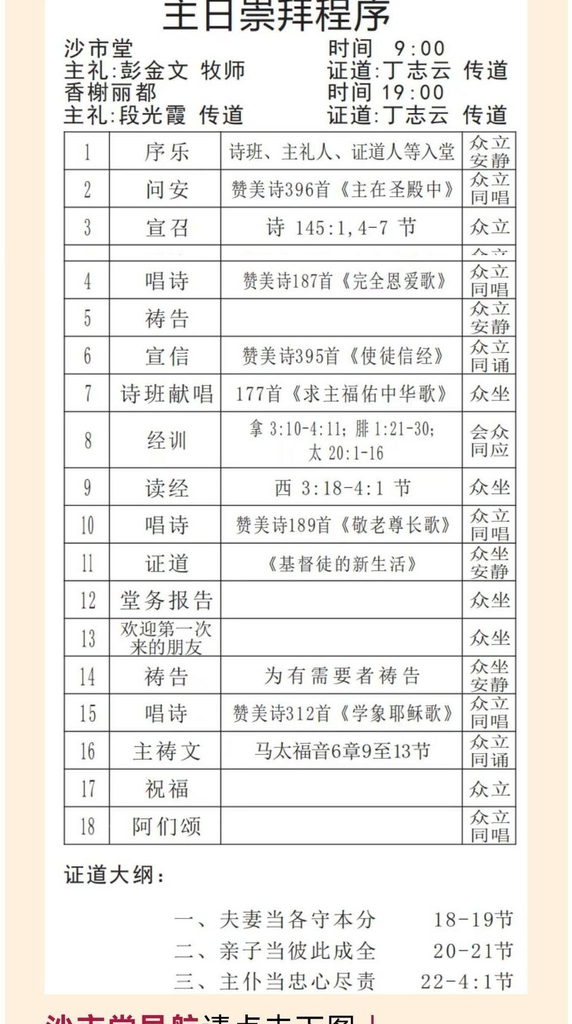

**赞美诗 187《完全恩爱歌》** ← 第4项 item 4

[figure not shown]

**赞美诗 177《求主福佑中华歌》** ← 第7项 item 7

[figure not shown]

**赞美诗 189《敬老尊长歌》** ← 第10项 item 10

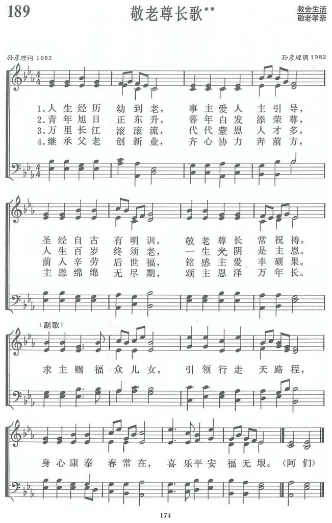

**赞美诗 312《学象耶稣歌》** ← 第15项 item 15

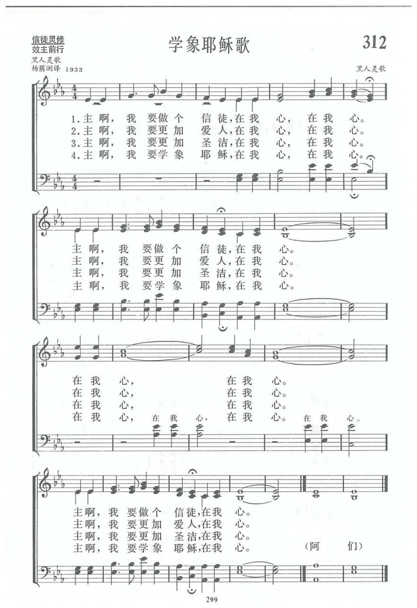

**赞美诗 396《主在圣殿中》** ← 第2项 item 2

[figure not shown]

**赞美诗 395《使徒信经》(1)** ← 第6项 item 6

[figure not shown]

**赞美诗 395《使徒信经》(2)** ← 第6项 item 6

[figure not shown]